# Bayesian data analysis with PyMC3

## Thomas Wiecki

## Quantopian Inc.

# About me

- PhD candidate at Brown studying decision making using Bayesian modeling.
- Quantitative Researcher at [Quantopian Inc](https://www.quantopian.com): Building the world's first algorithmic trading platform in the web browser.

# Why should you care about Bayesian Data Analysis?

```python
Image('backbox_ml.png')
```

[figure not shown]

- Blackbox models not good at conveying **what** they have learned.

```python
Image('openbox_pp.png')
```

[figure not shown]

# Probabilistic Programming

- Model **unknown causes** of a phenomenon as **random variables**.
- Write a **programmatic story** of how **unknown causes** result in **observable data**.
- Use **Bayes formula** to invert generative model to infer **unknown causes**.

# Random Variables as Probability Distributions

- Represents our beliefs about an unknown state.
- Probability distribution assigns a probability to each possible state.
- **Not** a single number (e.g. most likely state).

# Coin-flipping experiment.

- Given multiple flips, what is probability of getting heads?
- Maximum Likelihood answer:

$$\frac{\# \text{heads}}{\text{total throws}}$$

- However:

$$\frac{50}{100} = \frac{1}{2}$$

- Clearly something is missing!
- **Quantification of uncertainty.**

Moreover...

- Consider a single flip which comes up heads:

$$ P(\text{heads}) = \frac{1}{1} = 1 $$

- Again, this doesn't seem right.
- Incorporate **prior knowledge.**

## $$ \text{Express probability of heads as random variable } \theta$$

```python
stats.beta(2,2).rvs(1)
```

```
array([ 0.37833632])
```

```
719
Average return -0.613351877608
```

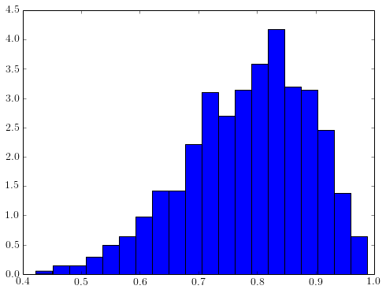

```python
import random
import numpy as np

def choose_coin():
    return stats.beta(2, 2).rvs(1) # random.uniform(0,1) # np.random.normal(0,1) #
# pylab.hist([choose_coin() for dummy in range(100000)], normed=True, bins=100)
successes = []
returns = 0.
for i in range(10000):
    prob_heads = choose_coin()
    results = [random.uniform(0,1) < prob_heads for dummy in range(10)]
    if results.count(True) == 9:
        successes.append(prob_heads)
        if random.uniform(0,1) < prob_heads:
            returns += -1
        else:
            returns += 1
fig = plt.figure(figsize=(8, 6))
ax = fig.add_subplot(111)
r = ax.hist(np.array(successes), normed=True, bins=20)
print len(successes)
print "Average return", returns / len(successes)
```

$$ \theta \sim \text{Beta}(2, 2) $$ $$ P(\theta) = \text{Beta}(2, 2) $$

$$ P(\theta | h=1) = \text{Beta}(3, 2) $$

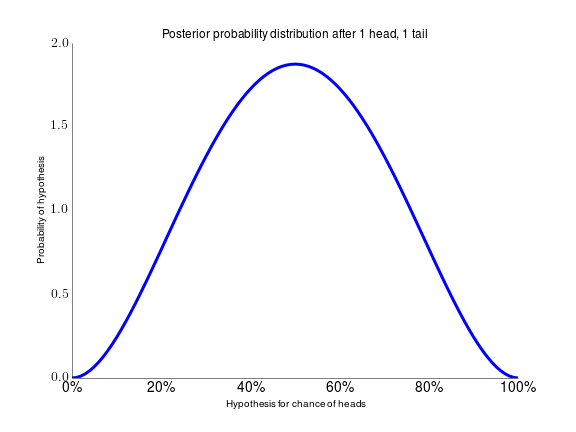

```python
Image('coin3.png')
```

$$ P(\theta | [h=1, t=1]) = \text{Beta}(3, 3) $$

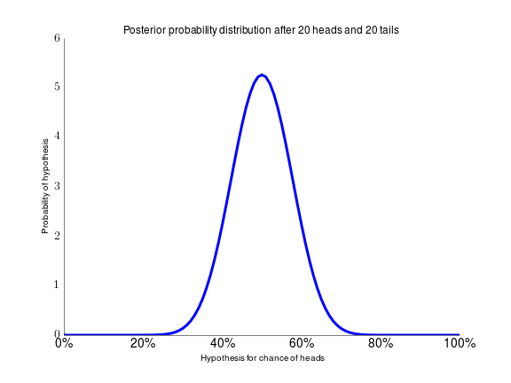

```python
Image('coin4.png')
```

$$ P(\theta | [h=20, t=20]) = \text{Beta}(22, 22) $$

# Bayes Formula

$$P(\theta| \text{data}) \propto P(\theta) \ast P(\text{data} |\theta)$$ $$\text{posterior} \propto \text{prior} \ast \text{likelihood}$$

$\theta$: Parameters of model (chance of getting heads)).

- Except in simple cases, **posterior impossible to compute** analytically.
- Blackbox **approximation** algorithm: Markov-Chain Monte Carlo (MCMC) instead draws **samples** from the posterior.

## Approximating the posterior with MCMC sampling

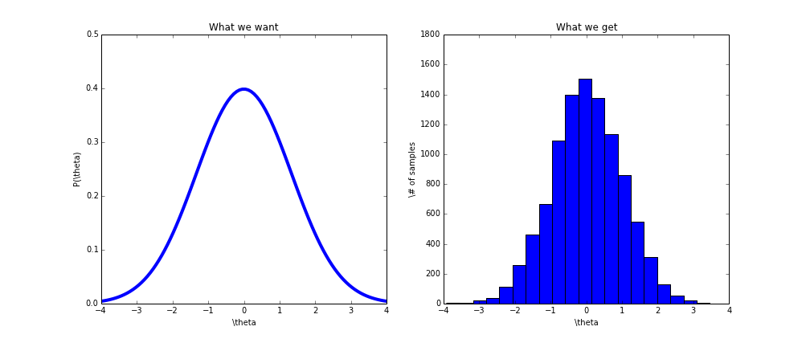

```python
Image('wantget.png')
```

# PyMC3

- Probabilistic Programming framework written in Python.
- Allows for construction of probabilistic models using intuitive syntax.
- Features advanced MCMC samplers.
- Fast: Just-in-time compiled by Theano.
- **Extensible**: easily incorporates custom MCMC algorithms and unusual probability distributions.

# Linear Models

- Assumes a linear relationship between two variables.
- E.g. stock price between Gold and Gold Miners.

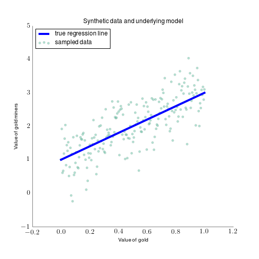

```python
Image('synth_data.png')
```

# Linear Regression

$$ y_i = \alpha + \beta \ast x_i + \epsilon $$

with $$ \epsilon \sim \mathcal{N}(0, \sigma^2) $$

## Probabilistic Reformulation

$$ y_i \sim \mathcal{N}(\alpha + \beta \ast x_i, \sigma^2) $$

### Priors

$$ \alpha \sim \mathcal{N}(0, 20^2) $$ $$ \beta \sim \mathcal{N}(0, 20^2) $$ $$ \sigma \sim \mathcal{U}(0, 20) $$

## Constructing model in PyMC3

```python
import pymc as pm

with pm.Model() as model: # model specifications in PyMC3 are wrapped in a with-statement
    # Define priors
    alpha = pm.Normal('alpha', mu=0, sd=20)
    beta = pm.Normal('beta', mu=0, sd=20)
    sigma = pm.Uniform('sigma', lower=0, upper=20)

    # Define linear regression
    y_est = alpha + beta * x

    # Define likelihood
    likelihood = pm.Normal('y', mu=y_est, sd=sigma, observed=y)

    # Inference!
    start = pm.find_MAP() # Find starting value by optimization
    step = pm.NUTS(state=start) # Instantiate MCMC sampling algorithm
    trace = pm.sample(2000, step, start=start, progressbar=False) # draw 2000 posterior samples using NUTS sampling
```

# Covenience function glm()

```python
with pm.Model() as model:
    # specify glm and pass in data. The resulting linear model, its likelihood and
    # and all its parameters are automatically added to our model.
    pm.glm.glm('y ~ x', data)
    step = pm.NUTS() # Instantiate MCMC sampling algorithm
    trace = pm.sample(2000, step, progressbar=False) # draw 2000 posterior samples using NUTS sampling
```

# Posterior

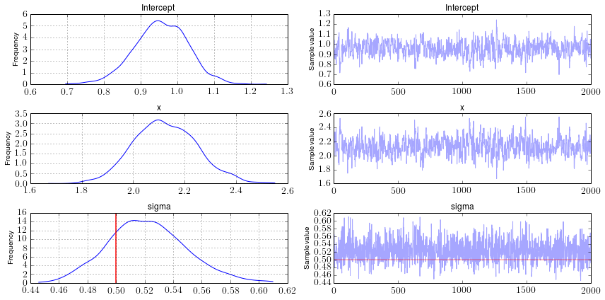

```python
fig = pm.traceplot(trace, lines={'alpha': 1, 'beta': 2, 'sigma': .5});
```

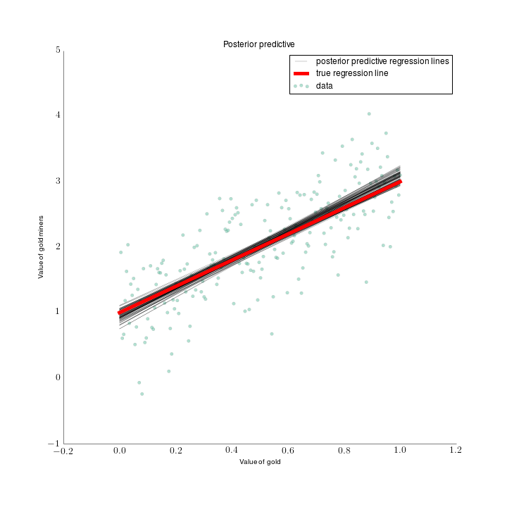

```python
Image('ppc1.png')
```

# Robust Regression

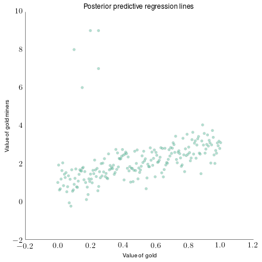

```python
# Add outliers
x_out = np.append(x, [.1, .15, .2, .25, .25])
y_out = np.append(y, [8, 6, 9, 7, 9])

data_out = dict(x=x_out, y=y_out)
fig = plt.figure(figsize=(7, 7))
ax = fig.add_subplot(111,  xlabel='Value of gold', ylabel='Value of gold miners', title='Posterior predictive regression lines')
ppl.scatter(ax, x_out, y_out, label='data')
```

```python
with pm.Model() as model:
    glm.glm('y ~ x', data_out)
    trace = pm.sample(2000, pm.NUTS(), progressbar=False)
```

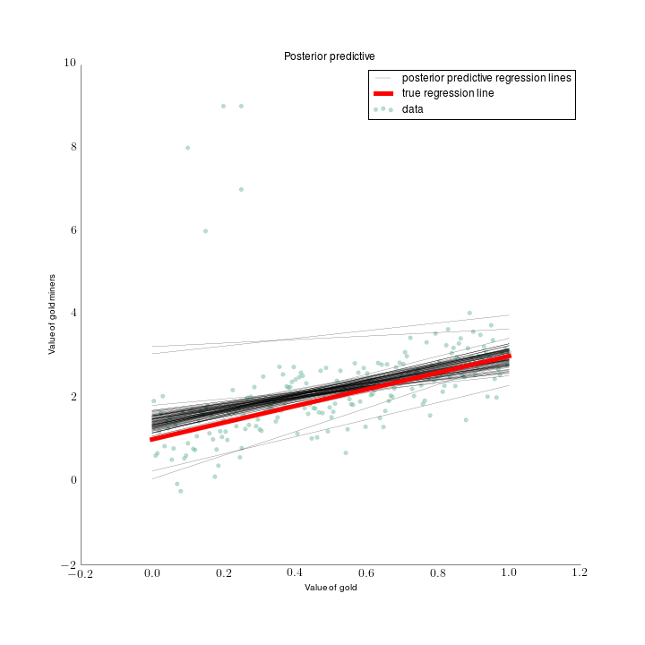

```python
Image('ppc2.png')
```

# Fit strongly biased by outliers

- Normal distribution has very light tails.
- -> sensitive to outliers.
- Instead, use Student T distribution with heavier tails.

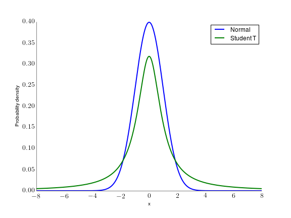

```python
Image('t-dist.png')
```

```python
with pm.Model() as model_robust:
    family = pm.glm.families.T()
    pm.glm.glm('y ~ x', data_out, family=family)

    trace_robust = pm.sample(2000, pm.NUTS(), progressbar=False)
```

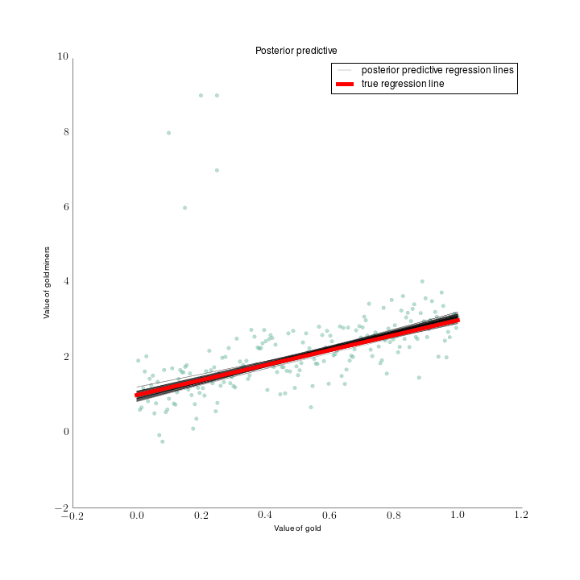

```python
Image('ppc3.png')
```

# Real-world example: Algorithmic Trading

- Pairtrading is a famous technique that plays two stocks against each other.
- For this to work, stocks must be correlated (cointegrated).
- One common example is the price of gold (GLD) and the price of gold mining operations (GDX).

```
GLD
GDX
```

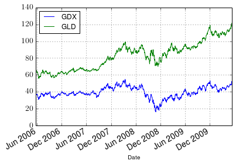

```python
import zipline
import pytz
from datetime import datetime
fig = plt.figure(figsize=(8, 4))

prices = zipline.data.load_from_yahoo(stocks=['GLD', 'GDX'],
                                 end=datetime(2013, 8, 1, 0, 0, 0, 0, pytz.utc)).dropna()[:1000]
prices.plot();
```

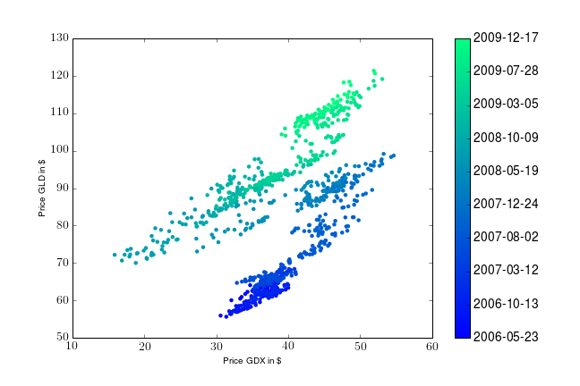

```python
Image('price_corr.png')
```

# Naive model assumes constant linear regression.

```python
with pm.Model() as model_reg:
    family = pm.glm.families.Normal()
    pm.glm.glm('GLD ~ GDX', prices, family=family)
    trace_reg = pm.sample(2000, pm.NUTS(), progressbar=False)
```

## Hm... kinda unsatisfying...

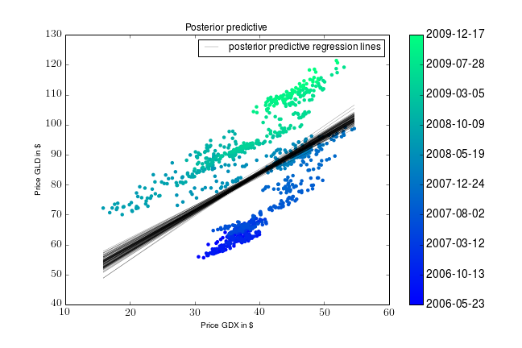

```python
Image('ppc4.png')
```

- Clearly the regression between GDX and GLD changes over time.
- But it does so gradually.
- Can we build a model that allows for gradual changes in the coefficients?
- YES!